# Hands-On Tutorials for Covariate Adjustment in Randomized Trials

2025-03-23

## Outline

- Overview: Open Source Software:
  - Group Sequential Designs, Information Monitoring
- Review Fixed Sample Size Plans in **R**
- Convert Fixed Sample Size to Group Sequential Design
- Analyze Example Datasets

## Software

- Planning, Analyzing Group Sequential Designs:
  - [rpact](https://www.rpact.org): [Tutorials & Vignettes](https://www.rpact.org/#learn-to-use-rpact)
  - [gsDesign](https://keaven.github.io/gsDesign/): [Web Interface](https://keaven.github.io/gsd-shiny/) and [related software](https://keaven.github.io/software/)
- Planning, Monitoring, Analyzing Information Monitored Designs
  - [impart](https://jbetz-jhu.github.io/impart/) - [Tutorials & Vignettes](https://jbetz-jhu.github.io/impart/articles/)

## MISTIE-III Trial - Effect Size \(h\): (Hanley et al. 2019)

- Outcome: Dichotomized Modified Rankin Scale:
  - \(0-3 \rightarrow 1\): Good Functional Outcome - Alive, Independent
  - \(4-6 \rightarrow 0\): Poor Functional Outcome
- Assumed \(Pr\{Y|A = 0\} = \pi_{0} \approx\) 0.25:
- Detect Risk Difference \(\delta_{RD} \ge\) 0.13: \(Pr\{Y|A = 1\} = \pi_{1} \ge\) 0.38
- Power = 0.8, Type I Error = 0.05: Two-sided test, 20% missing data
  - Just for demonstration: Not values from original study

```r
p0_design <- 0.25
risk_difference_design <- 0.13
p1_design <- p0_design + risk_difference_design
alpha_design <- 0.05
power_design <- 0.80
pr_missing <- 0.20
```

## MISTIE-III Trial - Fixed Sample Size \(N\):

- Determine Effect size \(h = 2\left(sin^{-1}\left(\sqrt{\pi_{1}}\right) - sin^{-1}\left(\sqrt{\pi_{0}}\right) \right) =\) 0.281

```r
pwr::ES.h(p1 = p1_design, p2 = p0_design)
## [1] 0.2812329
```

- Determine \(N\) **per arm** of complete observations

```r
n_per_arm_fixed <-
  pwr::pwr.2p.test(
    h = es_h_design,
    sig.level = alpha_design,
    power = power_design
  )$n %>% ceiling()

n_per_arm_fixed
## [1] 199
```

- We need 398 complete outcomes: Divide by fraction complete = 0.8 \(\rightarrow\) 498 participants

```r
ceiling(2*n_per_arm_fixed/(1 - pr_missing))
## [1] 498
```

## Group Sequential Design (GSD)

- 3 Stages: 2 Interim Analyses (50%, 75% of \(N\)) + Final Analysis
- Efficacy Bounds: O’Brien Fleming \(\alpha\)-spending Functions - No Futility

```r
information_rates <- c(0.50, 0.75, 1.00)
type_of_design_asof <- "asOF"
type_beta_spending_asof <- "none"

trial_design <-
  rpact::getDesignGroupSequential(
    alpha = alpha_design,
    beta = 1 - power_design,
    sided = test_sides,
    informationRates = information_rates,
    typeOfDesign = type_of_design_asof,
    typeBetaSpending = type_beta_spending_asof
  )

plot(trial_design) # Plot Boundaries
```

## O’Brien-Fleming: Efficacy Only

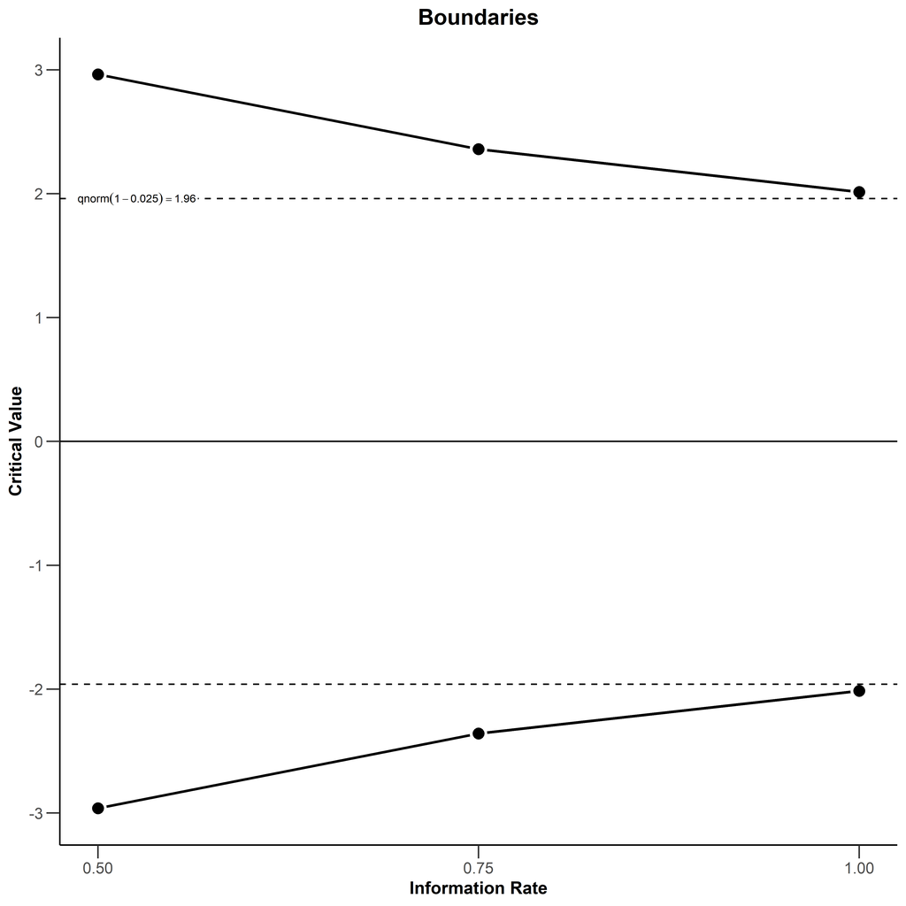

## O’Brien-Fleming: Efficacy & Futility

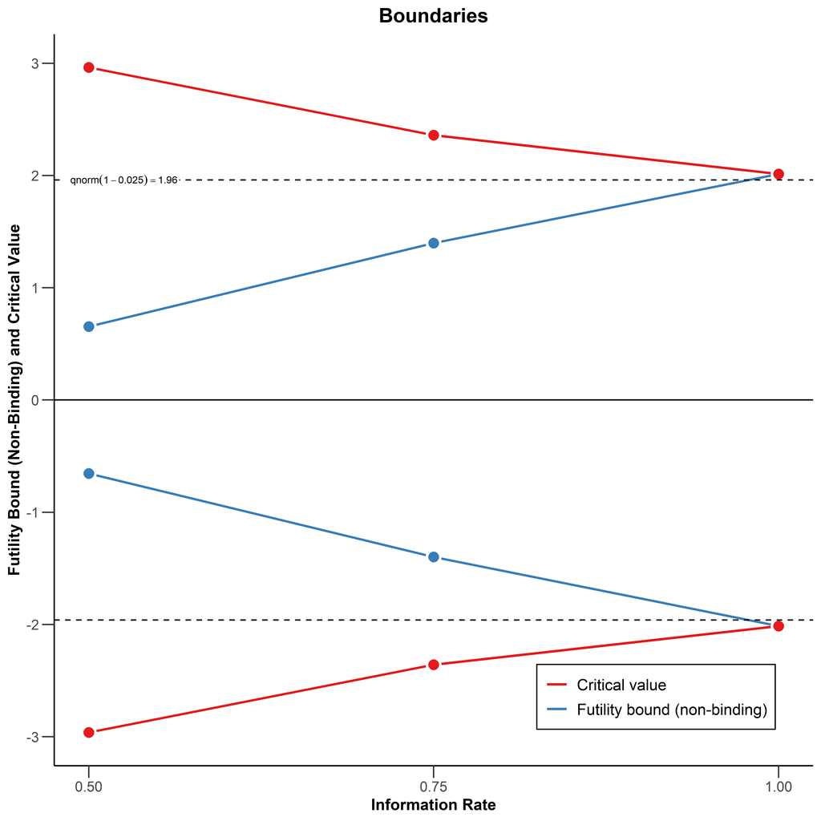

## Compute Sample Size Adjustment

```r
inflation_factor <-
  rpact::getDesignCharacteristics(
    design = trial_design_asof
  )$inflationFactor
n_total_gsd_asof <-
  ceiling(2*n_per_arm_fixed*inflation_factor_asof)
n_at_analyses_asof <-
  ceiling(information_rates*n_total_gsd_asof)
```

- Maximum Sample Size is 2% larger than Fixed Sample Size
- Potential to stop at \(N =\) 254 or 381

## Analyzing Group Sequential Designs

## Using the `impart` Package:

- **I**nformation **m**onitoring for **p**recision **a**daptive **r**andomized **t**rials
  - Using Covariate Adjustment in Group Sequential Designs: Focus
  - Designing, Monitoring, Analyzing trials with Information Monitoring: Later
- Group Sequential Designs:
  - Set up a GSD with [rpact](https://www.rpact.org) package
  - Set up a `monitored_design`: Stores settings for analyses: \(N_{max}\), RNG seeds, \(\theta_{0}\)
  - Perform analyses: gives an updated `monitored_design` to pass to next analysis
    - Keep going until stop for efficacy, futility, or fail to reject
  - Final analysis will contain entire history of study:
- Users can supply their own functions for analysis:
  - Standardization (Continuous, binomial); Marginal HR (Time-to-Event)

## `impart` - Setting Up a Design

```r
# Set up monitored design - **See .Rmd for details**
monitored_design_asof <-
  initialize_monitored_design(
    # Trial Design set up using rpact
    trial_design = trial_design_asof,
    # Null value of parameter
    null_value = 0,
    # Maximum Sample Size
    maximum_sample_size = n_total_gsd_asof,
    # Target precision: Based on assumed effect, Power, Alpha
    information_target = information_adaptive_asof,
    # Enforce Independent Increments with Orthogonalization
    orthogonalize = TRUE,
    # RNG Seed for analyses
    rng_seed_analysis = 54321
  )
```

## Interim Analysis 1/3: O-F Efficacy

```r
interim_analysis_asof_1 <-
  monitored_analysis(
    data = sim_miii_asof_ia_1, # Current Data
    monitored_design = monitored_design_asof, # Design Details
    estimation_function = standardization, # Function used for analysis
    estimation_arguments = # Arguments that `estimation_function` uses
      list(
        estimand = "difference",
        outcome_formula =
          mrs_356d_binary ~ tx + age + male + hx_cvd + hx_hyperlipidemia +
          on_anticoagulants + on_antiplatelets + ich_location + ich_s_volume +
          ivh_s_volume + gcs_category,
        family = binomial,
        treatment_column = "tx",
        outcome_indicator_column = ".r_3"
      ),
    # Optional function to adjust variance (e.g. for # of covariates)
    correction_function = standardization_correction
  )
```

## Interim Analysis 1 Results:

```r
# Decision
interim_analysis_asof_1$interim_analysis_1$decision_detail
## [1] "Continue - stage 1 of 3"

# Test statistics, Boundaries
interim_analysis_asof_1$interim_analysis_1$decision_data
##   test_statistic efficacy futility
## 1     -0.5363828 2.620028       -6
## 2             NA 2.393409       -6
## 3             NA 2.016382       NA
```

- Test statistic hasn’t exceeded any efficacy boundaries

## Interim Analysis 2/3: O-F Efficacy

```r
interim_analysis_asof_2 <-
  monitored_analysis(

    data = sim_miii_asof_ia_2, # Pass updated data
    monitored_design = interim_analysis_asof_1, # Pass previous analysis

    # Specify what to do for interim analysis 2
    estimation_function = standardization,
    estimation_arguments =
      list(
        estimand = "difference",
        outcome_formula =
          mrs_356d_binary ~ tx + age + male + hx_cvd + hx_hyperlipidemia +
          on_anticoagulants + on_antiplatelets + ich_location + ich_s_volume +
          ivh_s_volume + gcs_category,
        family = binomial,
        treatment_column = "tx",
        outcome_indicator_column = ".r_3"
      ),

    correction_function = standardization_correction
  )
```

## Interim Analysis 2 Results:

```r
# Decision
interim_analysis_asof_2$interim_analysis_2$decision_detail
## [1] "Continue - stage 2 of 3"

# Test statistics, Boundaries
interim_analysis_asof_2$interim_analysis_2$decision_data
##   test_statistic efficacy futility
## 1     -0.5363828 2.620028       -6
## 2     -0.4486519 2.117203       -6
## 3             NA 2.065338       NA

# Entire history of results are nested within the result
names(interim_analysis_asof_2)
## [1] "original_design"    "interim_analysis_1" "interim_analysis_2"
```

- Test statistic hasn’t exceeded any efficacy boundaries

## Final Analysis: O-F Efficacy

```r
final_analysis_asof <-
  monitored_analysis(

    data = sim_miii_asof_ia_3, # Pass updated data
    monitored_design = interim_analysis_asof_2, # Pass previous analysis

    # Specify what to do for interim analysis 2
    estimation_function = standardization,
    estimation_arguments =
      list(
        estimand = "difference",
        outcome_formula =
          mrs_356d_binary ~ tx + age + male + hx_cvd + hx_hyperlipidemia +
          on_anticoagulants + on_antiplatelets + ich_location + ich_s_volume +
          ivh_s_volume + gcs_category,
        family = binomial,
        treatment_column = "tx",
        outcome_indicator_column = ".r_3"
      ),

    correction_function = standardization_correction
  )
```

## Final Analysis Results:

```r
# Decision
final_analysis_asof$final_analysis$decision_detail
## [1] "Fail to reject: stage 3 of 3"

# Test statistics, Boundaries
final_analysis_asof$final_analysis$decision_data
##   test_statistic efficacy futility
## 1    -0.53638277 2.620028       -6
## 2    -0.44865191 2.117203       -6
## 3    -0.09662835 2.194341       NA

# Entire history of results are nested within the result
names(final_analysis_asof)
## [1] "original_design"    "interim_analysis_1" "interim_analysis_2"
## [4] "final_analysis"
```

## Add Futility Stopping:

## O-F Efficacy **+ Futility** - Analysis 1

```r
interim_analysis_asof_bsof_1 <-
  monitored_analysis(

    data = sim_miii_asof_bsof_ia_1,
    monitored_design = monitored_design_asof_bsof, # Design Details

    estimation_function = standardization,
    estimation_arguments =
      list(
        estimand = "difference",
        outcome_formula =
          mrs_356d_binary ~ tx + age + male + hx_cvd + hx_hyperlipidemia +
          on_anticoagulants + on_antiplatelets + ich_location + ich_s_volume +
          ivh_s_volume + gcs_category,
        family = binomial,
        treatment_column = "tx",
        outcome_indicator_column = ".r_3"
      ),
    correction_function = standardization_correction
  )
```

## Interim Analysis 1 Results:

```r
# Decision
interim_analysis_asof_bsof_1$interim_analysis_1$decision_detail
## [1] "Futility - stage 1 of 3"

# Test statistics, Boundaries
interim_analysis_asof_bsof_1$interim_analysis_1$decision_data
##   test_statistic efficacy futility
## 1     -0.1306888 2.658823 1.035047
## 2             NA 2.387824 1.368953
## 3             NA 2.016162       NA
```

- Recommend to stop: Futility

## Conclusions

- [rpact](https://www.rpact.org) and [gsDesign](https://keaven.github.io/gsDesign/): Great software, vignettes - Also see (Jennison and Turnbull 1999)
- Specify Initial Design:
- First Analysis: Pass Design, Analysis + Arguments, Data
- Additional Analyses:
  - Pass previous result, Analysis + Arguments, Updated Data
- Repeat until stopping criteria met: Each result nested in object

## References

Hanley, Daniel F, Richard E Thompson, Michael Rosenblum, Gayane Yenokyan, Karen Lane, Nichol McBee, Steven W Mayo, et al. 2019. “Efficacy and Safety of Minimally Invasive Surgery with Thrombolysis in Intracerebral Haemorrhage Evacuation ( MISTIE III): A Randomised, Controlled, Open-Label, Blinded Endpoint Phase 3 Trial.” *The Lancet* 393 (10175): 1021–32. https://doi.org/10.1016/s0140-6736(19)30195-3.

Jennison, Christopher, and Bruce W. Turnbull. 1999. *Group Sequential Methods with Applications to Clinical Trials*. Chapman; Hall/ CRC. https://doi.org/10.1201/9780367805326.